# MATH 208 Final Project

```r
library(tidyverse)
```

```r
library(rpart.plot)
library(rpart)
FlixGem <- read_csv("Final_Project_FlixGem.csv")
```

## Task 1: Data wrangling and exploratory data analyses

```r
FlixGem_task1 <- filter(FlixGem, `Series or Movie`=="Movie")
FlixGem_task1a <- FlixGem_task1 %>% drop_na(`Hidden Gem Score`) %>% drop_na(Languages) %>% drop_na(Runtime)

FlixGem_task1a %>% group_by(Languages) %>%
  summarise(count=n()) %>%
  mutate(prop=count/sum(count)) %>% arrange(desc(prop))
```

```
## # A tibble: 1,086 × 3
##    Languages        count    prop
##    <chr>            <int>   <dbl>
##  1 English           2801 0.404
##  2 Japanese           446 0.0643
##  3 English, Spanish   222 0.0320
##  4 Korean             186 0.0268
##  5 Hindi              168 0.0242
##  6 English, French    127 0.0183
##  7 Spanish            109 0.0157
##  8 French              85 0.0123
##  9 German              54 0.00779
## 10 Mandarin            49 0.00706
## # … with 1,076 more rows
```

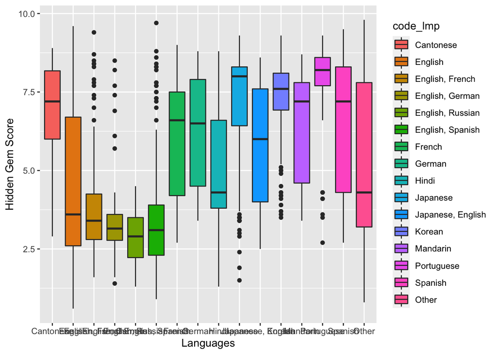

```r
# the remaining rows have very small proportion (less than 0.00649), so lump them together
FlixGem_task1a_lump <- FlixGem_task1a %>% mutate(code_lmp = fct_lump(Languages, 15))

# Hidden Gem Score vs. Languages
ggplot(FlixGem_task1a_lump,aes(x=code_lmp,y=`Hidden Gem Score`,fill=code_lmp)) + geom_boxplot() + xlab("Languages")
```

```r
splited <- strsplit(FlixGem_task1a$Languages, split = ",")
language_table = data.frame(Title= rep(FlixGem_task1a$Title, sapply(splited, length)),`Hidden Gem Score` = rep(FlixGem_task1a$`Hidden Gem Score`, sapply(splited, length)), Languages = unlist(splited))

# count the number of languages used in each movie
language_count <- language_table %>% group_by(Title,Hidden.Gem.Score) %>% summarise(count=n())
```

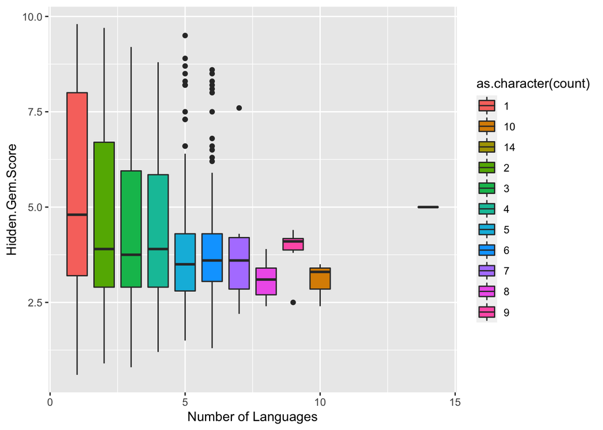

```r
# Hidden Gem Score vs. Number of Languages
ggplot(language_count ,aes(x = count, y = Hidden.Gem.Score, fill = as.character(count), group = count)) +  geom_boxplot() + xlab("Number of Languages")
```

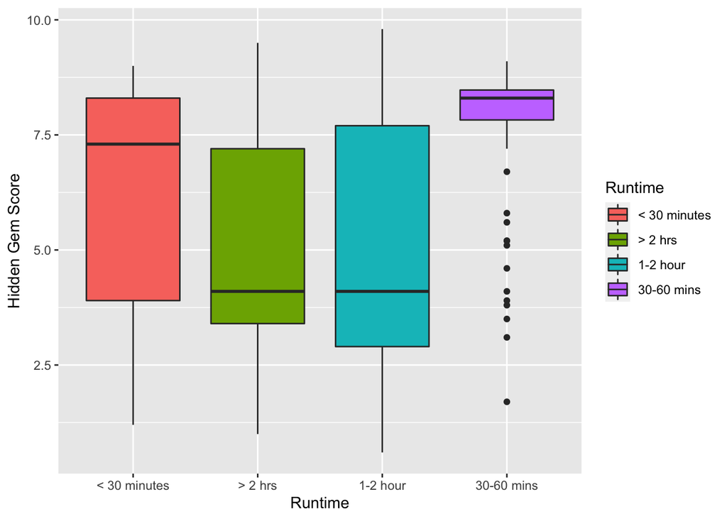

```r
# Hidden Gem Score vs. Runtime
ggplot(FlixGem_task1a,aes(x=Runtime,y=`Hidden Gem Score`,fill=Runtime)) + geom_boxplot()
```

#### The Hidden Gem Score seems to have weak association with the languages (either category or number) used in the film.

#### Based on languages that has been used in a large proportion among all Movies, the average Hidden Gem Scores of movies are greater than or equal to 5.0 are associated with “Cantonese, French, German, Japanese, ‘Japanese and English’, Korean, Portuguese, Spanish”; the average Hidden Gem Scores of movies are less than or equal to 5.0 are associated with “English, ‘English and French’, ‘English and German’, ‘English and Russian’, ‘English and Spanish’, Hindi”.

#### The graph for counts of language shows the association between Hidden Gem Score and number of languages. The number of languages here means how many languages are included for one movie. For instance, the Snowroller movie has Swedish, English, German,Norwegian. Thus, it counts four for the num of languages. The intention here is to see if more or less language versions of movies will affect the Hidden Gem Score.

#### From the graph, the mean score of only one kind of language is a bit higher than the others, but it does not exceed score 5. Also, the boxplot for movies with only one language shows wider ranges of scores from score 3-8.

#### And counts of languages from 2-7 have almost the same mean score with few fluctuations.

#### In conclusion, it is not easy to see there is an association between Hidden Gem Score and quantities of languages.

#### The Hidden Gem Score seems to have strong association with the Runtime Category of the film. Movies which are less than 60 minutes have a higher average Hidden Gem Score, around 7.5-8. People especially score higher for movies with 30-60 minutes.Movies which are 1-2 hours or larger than 2 hours only get around 4 Hidden Gem Score. Thus, the boxplot shows a significant relationship between Runtime Category and the Hidden Gem Score.

```r
FlixGem_task1b <- FlixGem_task1 %>% drop_na(`Hidden Gem Score`)

# correlation between IMDb and Hidden Gem Score
FlixGem_task1_IMDb <- FlixGem_task1b %>% drop_na(`IMDb Score`)
FlixGem_task1_IMDb %>% summarise(cor_IMDb = cor(`IMDb Score`,`Hidden Gem Score`))
```

```
## # A tibble: 1 × 1
##   cor_IMDb
##      <dbl>
## 1    0.384
```

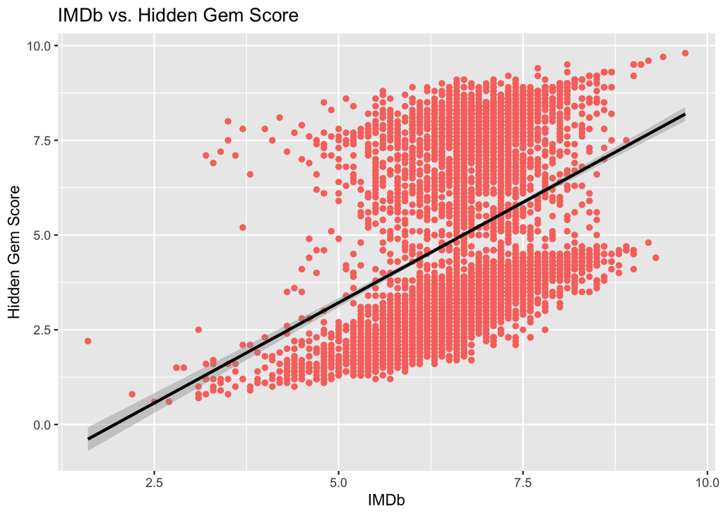

```r
ggplot(FlixGem_task1_IMDb,aes(x=`IMDb Score`,y=`Hidden Gem Score`, color="red")) + geom_point() + labs(x="IMDb", y="Hidden Gem Score", title="IMDb vs. Hidden Gem Score") + theme(legend.position = "none") + geom_smooth(formula=y ~ x, method="lm",col="black")
```

```r
# correlation between Rotten Tomatoes Score and Hidden Gem Score
FlixGem_task1_tomato <- FlixGem_task1b %>% drop_na(`Rotten Tomatoes Score`)
FlixGem_task1_tomato %>% summarise(Cor_RottenTomatoes = cor(`Rotten Tomatoes Score`,`Hidden Gem Score`))
```

```
## # A tibble: 1 × 1
##   Cor_RottenTomatoes
##                <dbl>
## 1              0.588
```

[figure not shown]

```r
ggplot(FlixGem_task1_tomato,aes(x=`Rotten Tomatoes Score`,y=`Hidden Gem Score`)) + geom_point(color="lightblue") + labs(x="Rotten Tomatoes Score", y="Hidden Gem Score", title="Rotten Tomatoes Score vs. Hidden Gem Score") + theme(legend.position = "none") + geom_smooth(formula=y ~ x,method="lm",col="black")
```

```r
# correlation between Metacritic Score and Hidden Gem Score
FlixGem_task1_Metacritic <- FlixGem_task1b %>% drop_na(`Metacritic Score`)
FlixGem_task1_Metacritic  %>% summarise(Cor_Metacritic = cor(`Metacritic Score`,`Hidden Gem Score`))
```

```
## # A tibble: 1 × 1
##   Cor_Metacritic
##            <dbl>
## 1          0.604
```

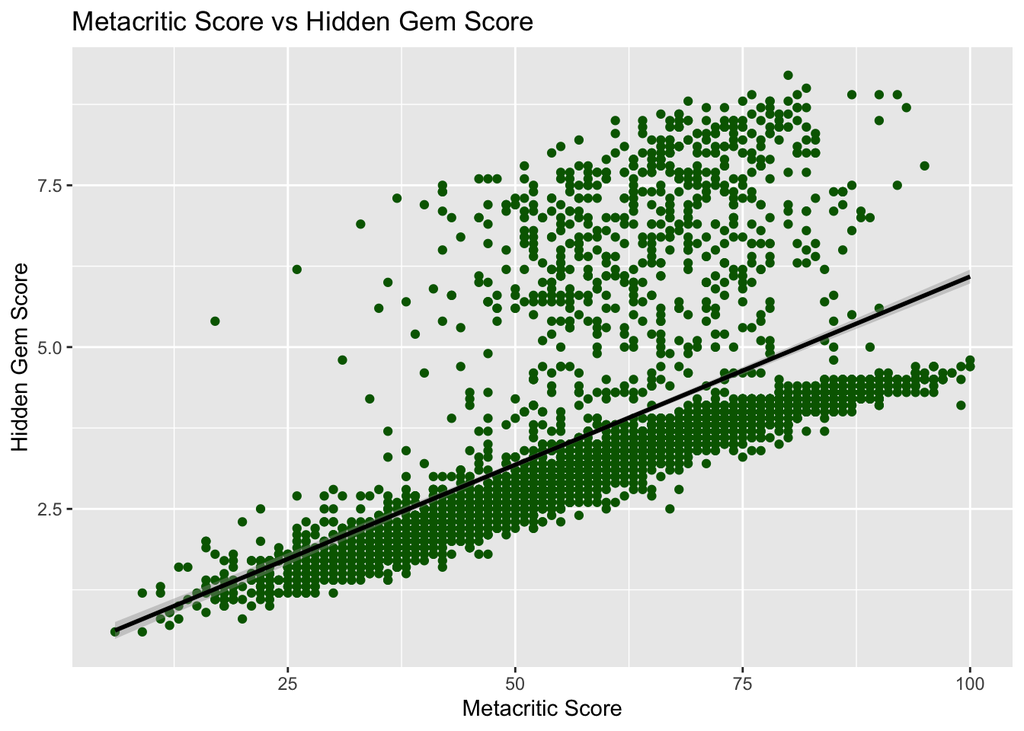

```r
ggplot(FlixGem_task1_Metacritic, aes(x=`Metacritic Score`,y=`Hidden Gem Score`)) + geom_point(color="darkgreen") + labs(x="Metacritic Score", y="Hidden Gem Score",
title="Metacritic Score vs Hidden Gem Score") + theme(legend.position = "none") + geom_smooth(formula = y~x, method="lm",col="black")
```

#### For IMDB and Hidden Gem Score , we get 0.3836269 by calculating the coefficient of correlation. Since the number is bigger than 0, but smaller than 0.5, it is a positive weak correlation. Thus, IMDB is not significantly correlated with Hidden Gem Score.

#### For Rotten Tomatoes Score and Hidden Gem Score, we get 0.587579, which is higher than correlation of IMDB. It is a positive moderate correlation.

#### For Metacritic and Hidden Gem Score, we get 0.6043788, which also indicates a positive moderate correlation.

#### Thus, based on the calculation and the scatterplot, both Rotten Tomatoes Score and Metacritic shows there is a moderate association with Hidden Gem Score.

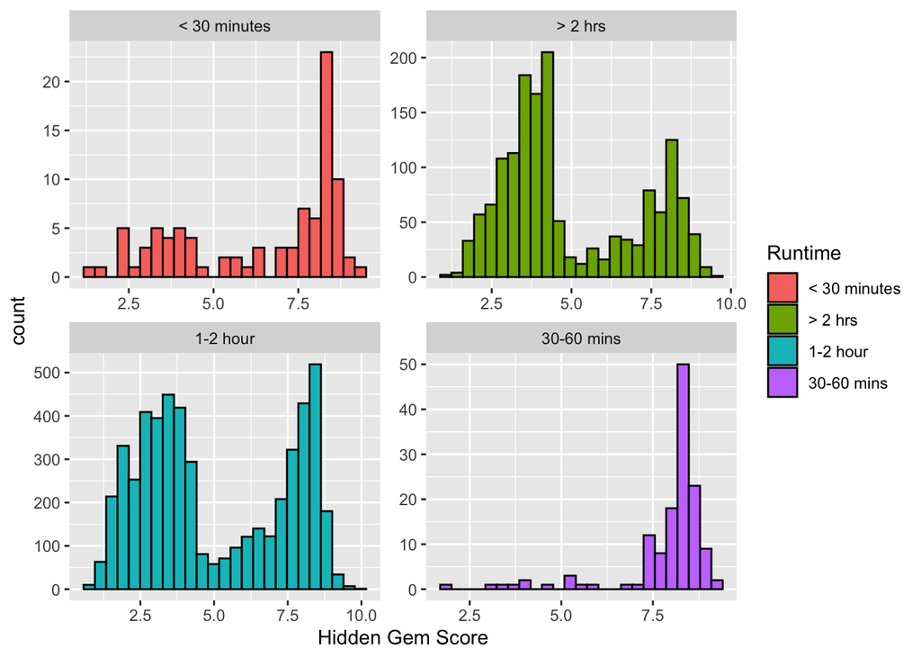

```r
FlixGem_task1c <- FlixGem_task1 %>% drop_na(`Hidden Gem Score`) %>% drop_na(Runtime)

ggplot(FlixGem_task1c, aes(x=`Hidden Gem Score`, group = Runtime, fill = Runtime)) + geom_histogram(bins=25,col="black") + facet_wrap(~Runtime, scales="free")
```

#### Therefore, the company’s theory that people are becoming more accepting of longer movies because they can watch them at home on Netflix and other content-collecting sites is not applicable to most people – it is over-generalised.

## Task 2: Factors of the Hidden Gem Score

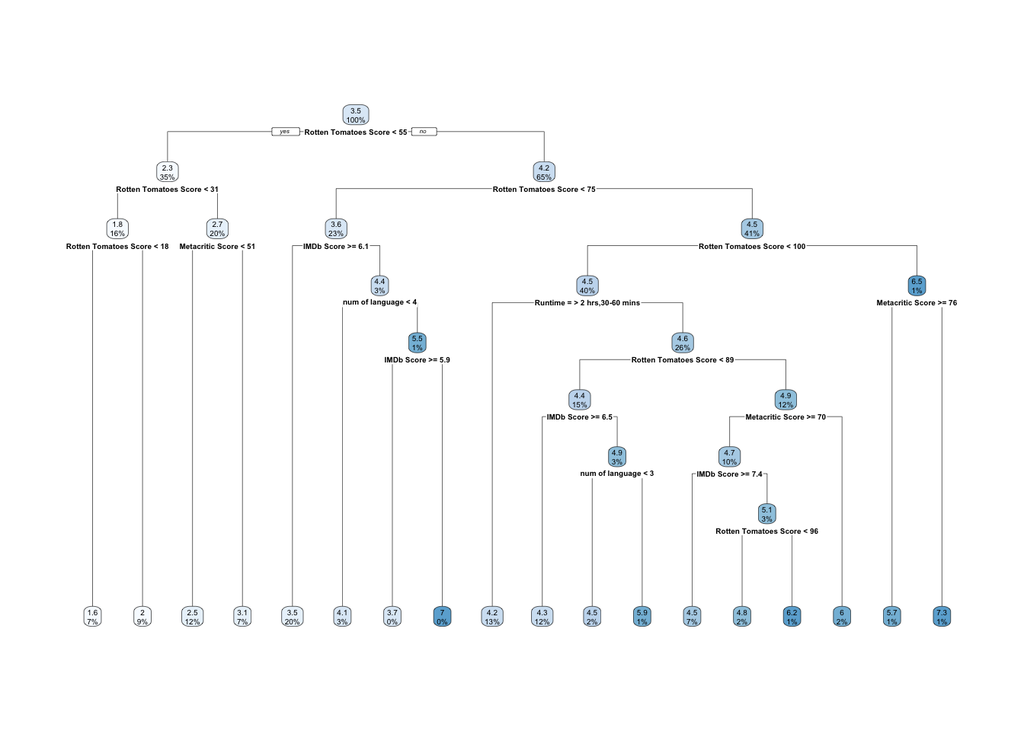

```r
# drop all the NA values
FlixGem_task2 = FlixGem  %>% drop_na(`Hidden Gem Score`)%>% drop_na(Languages) %>% drop_na(Runtime) %>% drop_na(`IMDb Score`) %>% drop_na(`Rotten Tomatoes Score`)  %>% drop_na(`Metacritic Score`) %>% select(`Hidden Gem Score`,Runtime,Languages,`IMDb Score`,`Rotten Tomatoes Score`,`Metacritic Score`,Title)

# split Languages to get the number of languages for each movie
s <- strsplit(FlixGem_task2$Languages, split = ",")
#rebuild the table
Language_table3 = data.frame(Title= rep(FlixGem_task2$Title,sapply(s, length)),
                             Runtime= rep(FlixGem_task2$Runtime, sapply(s, length)),
                            `Hidden Gem Score` = rep(FlixGem_task2$`Hidden Gem Score`, sapply(s, length)),
                            Languages = unlist(s),
                            `Rotten Tomatoes Score` = rep(FlixGem_task2$`Rotten Tomatoes Score`, sapply(s, length)),
                            `Metacritic Score` = rep(FlixGem_task2$`Metacritic Score`, sapply(s, length)),
                            `IMDb Score` = rep(FlixGem_task2$`IMDb Score`, sapply(s, length))
                            )

Language_table3 = Language_table3 %>% group_by(Title,Hidden.Gem.Score) %>% mutate(num_of_language = n())

# select columns
Language_table3  = Language_table3[,c("Hidden.Gem.Score","Runtime","IMDb.Score","Rotten.Tomatoes.Score","Metacritic.Score","num_of_language")]


# factor the Runtime
Language_table3$Runtime = factor(Language_table3$Runtime)

# labeling
`Hidden Gem Score` = Language_table3$Hidden.Gem.Score
Runtime = Language_table3$Runtime
`IMDb Score` = Language_table3$IMDb.Score
`Rotten Tomatoes Score` = Language_table3$Rotten.Tomatoes.Score
`Metacritic Score` = Language_table3$Metacritic.Score
`num of language` = Language_table3$num_of_language

# regression tree
a = rpart(formula = `Hidden.Gem.Score` ~ Runtime + `IMDb Score` + `Rotten Tomatoes Score` + `Metacritic Score` + `num of language`,
          data = Language_table3, method = "anova",
         control = list(minsplit = 11, maxdepth = 8, cp = 0.003))

rpart.plot(a)
```

## Task 3: An H-index for directors

```r
FlixGem_task3 <- FlixGem  %>% drop_na(`Hidden Gem Score`) %>% drop_na(Director)
FlixGem_task3_count <- FlixGem_task3 %>% group_by(Director) %>% mutate(film_num = n()) %>% mutate(HG_H = NA)

# initialize the indices
counter = 1
idx = 1

# fill HG-H index in the tibble
for (i in FlixGem_task3_count$Director){
  score <- filter(FlixGem_task3_count, Director==i)$`Hidden Gem Score`
  while (counter <= FlixGem_task3_count$film_num[idx]){
    accumu = 0
    for (s in score){
      if(counter <= s){
        accumu = accumu + 1
      }
    }
    if (accumu >= counter){
        FlixGem_task3_count$HG_H[idx] = counter
    }
    counter = counter + 1
  }
  idx = idx + 1
  counter = 1
}

# the top 10 directors according to an Hidden Gem H-index
FlixGem_task3_count_unique <- FlixGem_task3_count[,c("Director", "HG_H")] %>% unique() %>% arrange(desc(HG_H))
FlixGem_task3_count_unique[1:10,]
```

```
## # A tibble: 10 × 2
## # Groups:   Director [10]
##    Director                HG_H
##    <chr>                  <dbl>
##  1 Cathy Garcia-Molina        8
##  2 Tsutomu Shibayama          8
##  3 Raúl Campos, Jan Suter     8
##  4 Johnnie To                 7
##  5 Sang-soo Hong              7
##  6 Eric Khoo                  7
##  7 Marcus Raboy               7
##  8 Jing Wong                  7
##  9 Lance Bangs                7
## 10 Jay Chapman                7
```